# Application de DBSCAN

FX Jollois

11 mars 2022

## Données

Nous allons continuer à utiliser le jeu de données “Spotify” (csv à télécharger si nécessaire). Pour cela, nous allons les charger, et utiliser les packages `readr` (chargement de données), `tidyr` (rotation de données) et `dplyr` (manipulation de données). Ces trois packages proviennent du [`tidyverse`](https://www.tidyverse.org/) (en plus de `ggplot2` - réalisation de graphiques), ensemble de packages très puissants pour l’analyse de données.

```r
library(readr)
library(tidyr)
library(dplyr)
library(ggplot2)

songs = read_csv("spotify-2017songs.csv")
songs_num = songs %>%
  select(acousticness, danceability, energy, instrumentalness, liveness, speechiness, valence) %>%
  # mutate_all(scale) %>%
  tibble()
```

|  | acousticness | danceability | energy | instrumentalness | liveness | speechiness | valence |
| --- | --- | --- | --- | --- | --- | --- | --- |
| 1 | 0.0102 | 0.833 | 0.434 | 0.0219 | 0.165 | 0.431 | 0.286 |
| 2 | 0.199 | 0.743 | 0.359 | 0.00611 | 0.137 | 0.0794 | 0.588 |
| 3 | 0.0344 | 0.838 | 0.412 | 0.000234 | 0.159 | 0.289 | 0.173 |
| 4 | 0.604 | 0.494 | 0.338 | 0.51 | 0.0922 | 0.0261 | 0.23 |
| 5 | 0.18 | 0.678 | 0.561 | 0.512 | 0.439 | 0.0694 | 0.904 |
| 6 | 0.00479 | 0.804 | 0.56 | 0 | 0.164 | 0.185 | 0.264 |
| 7 | 0.0145 | 0.739 | 0.472 | 7.27e-06 | 0.207 | 0.156 | 0.308 |
| 8 | 0.0202 | 0.266 | 0.348 | 0.664 | 0.16 | 0.0371 | 0.393 |
| 9 | 0.0481 | 0.603 | 0.944 | 0 | 0.342 | 0.347 | 0.398 |
| 10 | 0.00208 | 0.836 | 0.603 | 0 | 0.571 | 0.237 | 0.386 |

[output cut: 2007 more lines]

## Recherche des paramètres

Nous sommes en dimension 7, la proposition de base est donc de choisir $MinPts = 14$. Nous allons nous basé sur cette option.

Pour $\varepsilon$, nous devons créer le graphique des $k\text{-}dist$ (avec $k=14$) de chaque point, triées dans l’ordre décroissant. Ici, nous avons 2017 individus, ce qui reste raisonnable. Dans le cas de données de tailles plus importantes, nous aurions dû procédé à un échantillonage (voire plusieurs) pour chercher cette valeur.

Nous calculons d’abord la matrice de distance :

```r
d = dist(songs_num)
```

```
##         1      2      3      4      5      6      7      8      9
## 2  0.5150
## 3  0.1858 0.5056
## 4  0.9420 0.7832 0.8860
## 5  0.9471 0.7018 0.9959 0.9164
## 6  0.2797 0.4458 0.2075 0.8922 0.8985
## 7  0.2977 0.3688 0.2281 0.8495 0.8472 0.1292
## 8  0.9528 0.8560 0.9402 0.6693 0.7770 0.9022 0.8388
## 9  0.6049 0.7310 0.6526 1.0686 0.8800 0.5154 0.5525 1.0196
## 10 0.4915 0.6008 0.5053 1.0525 0.7965 0.4314 0.4146 1.0198 0.4872
```

Ensuite, nous la transformons en matrice (pour la manipuler ensuite)

```r
m = as.matrix(d)
```

```
##         1      2      3      4      5      6      7      8      9     10
## 1  0.0000 0.5150 0.1858 0.9420 0.9471 0.2797 0.2977 0.9528 0.6049 0.4915
## 2  0.5150 0.0000 0.5056 0.7832 0.7018 0.4458 0.3688 0.8560 0.7310 0.6008
## 3  0.1858 0.5056 0.0000 0.8860 0.9959 0.2075 0.2281 0.9402 0.6526 0.5053
## 4  0.9420 0.7832 0.8860 0.0000 0.9164 0.8922 0.8495 0.6693 1.0686 1.0525
## 5  0.9471 0.7018 0.9959 0.9164 0.0000 0.8985 0.8472 0.7770 0.8800 0.7965
## 6  0.2797 0.4458 0.2075 0.8922 0.8985 0.0000 0.1292 0.9022 0.5154 0.4314
## 7  0.2977 0.3688 0.2281 0.8495 0.8472 0.1292 0.0000 0.8388 0.5525 0.4146
## 8  0.9528 0.8560 0.9402 0.6693 0.7770 0.9022 0.8388 0.0000 1.0196 1.0198
## 9  0.6049 0.7310 0.6526 1.0686 0.8800 0.5154 0.5525 1.0196 0.0000 0.4872
## 10 0.4915 0.6008 0.5053 1.0525 0.7965 0.4314 0.4146 1.0198 0.4872 0.0000
```

Maintenant, pour chaque ligne (ou colonne, résultat identique), on trie les valeurs par ordre croissants.

```r
m_tri = apply(m, 2, sort)
```

```
##            1      2      3      4      5      6      7      8      9     10
##  [1,] 0.0000 0.0000 0.0000 0.0000 0.0000 0.0000 0.0000 0.0000 0.0000 0.0000
##  [2,] 0.0000 0.1163 0.1749 0.2487 0.2604 0.1278 0.1172 0.2245 0.1514 0.1071
##  [3,] 0.1569 0.1228 0.1815 0.2517 0.3353 0.1292 0.1268 0.3206 0.1745 0.2522
##  [4,] 0.1754 0.1761 0.1858 0.2795 0.3929 0.1396 0.1292 0.3332 0.2140 0.2532
##  [5,] 0.1763 0.1796 0.1858 0.2826 0.3970 0.1434 0.1363 0.3934 0.2165 0.2579
##  [6,] 0.1858 0.1937 0.1995 0.2837 0.3980 0.1448 0.1520 0.4198 0.2231 0.2606
##  [7,] 0.2306 0.2020 0.2075 0.2926 0.4058 0.1451 0.1522 0.4452 0.2366 0.2654
##  [8,] 0.2321 0.2032 0.2086 0.3401 0.4092 0.1460 0.1541 0.4591 0.2425 0.2694
##  [9,] 0.2360 0.2045 0.2206 0.3405 0.4246 0.1473 0.1603 0.4608 0.2491 0.2789
## [10,] 0.2423 0.2056 0.2281 0.3615 0.4312 0.1504 0.1620 0.4662 0.2546 0.2907
## [11,] 0.2543 0.2066 0.2390 0.3717 0.4313 0.1605 0.1669 0.4764 0.2557 0.3009
## [12,] 0.2605 0.2129 0.2403 0.3801 0.4350 0.1628 0.1683 0.4786 0.2575 0.3019
## [13,] 0.2632 0.2136 0.2451 0.3826 0.4383 0.1652 0.1696 0.4836 0.2607 0.3077
## [14,] 0.2647 0.2166 0.2482 0.3878 0.4418 0.1759 0.1783 0.4865 0.2616 0.3088
## [15,] 0.2797 0.2173 0.2527 0.3904 0.4453 0.1769 0.1795 0.4883 0.2626 0.3128
## [16,] 0.2881 0.2191 0.2549 0.3973 0.4525 0.1781 0.1827 0.4974 0.2712 0.3129
## [17,] 0.2912 0.2212 0.2559 0.3996 0.4527 0.1818 0.1836 0.4979 0.2726 0.3145
## [18,] 0.2975 0.2220 0.2607 0.4005 0.4620 0.1820 0.1857 0.4990 0.2729 0.3168
## [19,] 0.2977 0.2236 0.2618 0.4098 0.4641 0.1854 0.1917 0.5098 0.2755 0.3226
## [20,] 0.3035 0.2329 0.2636 0.4147 0.4645 0.1870 0.2004 0.5111 0.2761 0.3254
```

Ensuite, on récupère la $k+1$ième valeur la plus petite ($+1$ car on aura le 0), donc la $k+1$ième ligne.

```r
v = m_tri[15,]
```

```
##      1      2      3      4      5      6      7      8      9     10
## 0.2797 0.2173 0.2527 0.3904 0.4453 0.1769 0.1795 0.4883 0.2626 0.3128
```

On créé un `data.frame` (plus exactement un `tibble` pour rester dans l’environnement `tidyverse`) contenant ces valeurs triées dans l’ordre décroissant.

```r
df = tibble(n = 1:2017, kdist = sort(v, decreasing = TRUE)) %>%
  mutate(diff = c(NA, -diff(kdist)))
```

|  | n | kdist | diff |
| --- | --- | --- | --- |
| 1 | 1 | 0.603420467004559 |  |
| 2 | 2 | 0.593173667655603 | 0.0102467993489558 |
| 3 | 3 | 0.592785838224902 | 0.000387829430700926 |
| 4 | 4 | 0.58792180888363 | 0.00486402934127195 |
| 5 | 5 | 0.58644318565399 | 0.00147862322964043 |
| 6 | 6 | 0.58215349230526 | 0.00428969334873019 |
| 7 | 7 | 0.577297011944458 | 0.00485648036080144 |
| 8 | 8 | 0.565432406998396 | 0.011864604946062 |
| 9 | 9 | 0.559594585403929 | 0.005837821594467 |
| 10 | 10 | 0.547411180010054 | 0.012183405393875 |

[output cut: 2007 more lines]

On va pouvoir afficher le graphique des $k\text{-}dist$ triées par ordre décroissant, et chercher un coude.

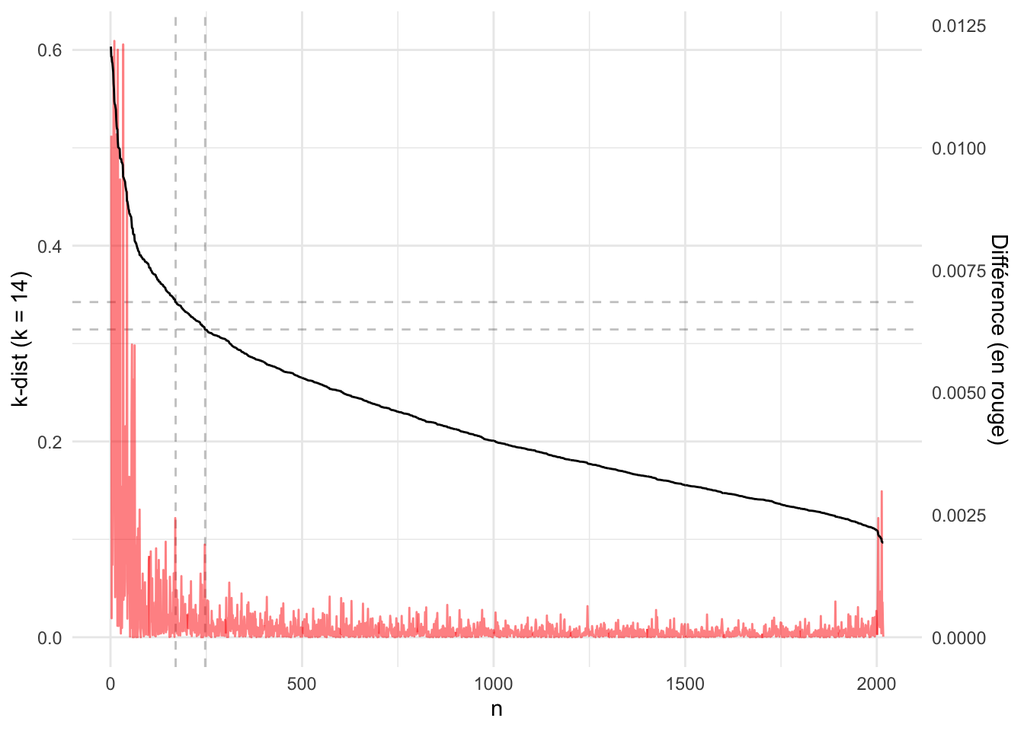

```r
coeff = 50
ggplot(df) +
  geom_vline(xintercept = c(170, 247), alpha = 0.25, lty = 2) +
  geom_hline(yintercept = df$kdist[c(170, 247)], alpha = 0.25, lty = 2) +
  geom_line(aes(n, diff * coeff), color = "red", alpha = 0.5) +
  geom_line(aes(n, kdist)) +
  scale_y_continuous(name = "k-dist (k = 14)", sec.axis = sec_axis( trans=~. / coeff, name="Différence (en rouge)")) +
  theme_minimal()
```

On remarque 2 pics en terme de différence, vers $\varepsilon=0.343$ et $\varepsilon=0.314$ (on testera probablement d’autres valeurs).

Nous pouvons chercher avec une valeur différente de $MinPts$ ($k$). Testez différentes valeurs (ici $k=5$).

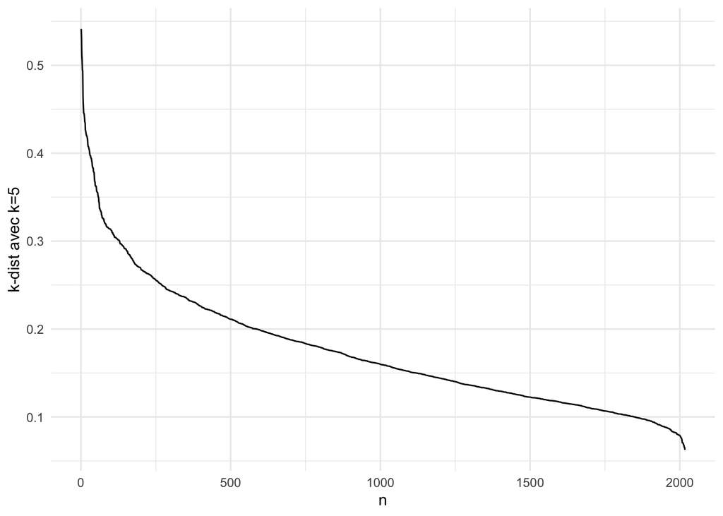

```r
k = 5
ggplot(tibble(n = 1:2017, kdist = sort(m_tri[k+1,], decreasing = TRUE)) %>%
         mutate(diff = c(NA, -diff(kdist)))) +
  geom_line(aes(n, kdist)) +
  labs(y = paste0("k-dist avec k=",k)) +
  theme_minimal()
```

## Recherche de la partition

On applique donc la mthode DBSCAN avec $\varepsilon=0.343$ et $MinPts=14$ dans un premier temps. On utilise ici la fonction `dbscan` du package `dbscan`.

```r
library(dbscan)
res = dbscan(songs_num, eps = .343, minPts = 14)
res
```

```
## DBSCAN clustering for 2017 objects.
## Parameters: eps = 0.343, minPts = 14
## The clustering contains 1 cluster(s) and 35 noise points.
##
##    0    1
##   35 1982
##
## Available fields: cluster, eps, minPts
```

```r
res = dbscan(songs_num, eps = .314, minPts = 14)
res
```

```
## DBSCAN clustering for 2017 objects.
## Parameters: eps = 0.314, minPts = 14
## The clustering contains 1 cluster(s) and 62 noise points.
##
##    0    1
##   62 1955
##
## Available fields: cluster, eps, minPts
```

On trouve encore une seule classe. On peut modifier aussi $MinPts$ pour avoir plus de classes. On va le doubler.

```r
res = dbscan(songs_num, eps = .314, minPts = 28)
res
```

```
## DBSCAN clustering for 2017 objects.
## Parameters: eps = 0.314, minPts = 28
## The clustering contains 2 cluster(s) and 108 noise points.
##
##    0    1    2
##  108 1844   65
##
## Available fields: cluster, eps, minPts
```

Après quelques tests, on peut affiner un peu en choisissant $\varepsilon=0.32$ et $MinPts=42$.

```r
res = dbscan(songs_num, eps = 0.32, minPts = 42)
res
```

```
## DBSCAN clustering for 2017 objects.
## Parameters: eps = 0.32, minPts = 42
## The clustering contains 3 cluster(s) and 202 noise points.
##
##    0    1    2    3
##  202 1679   79   57
##
## Available fields: cluster, eps, minPts
```

Nous obtenons ici 3 classes (une très grande et 2 petites), ainsi que 202 points *outliers*. Voici la caractérisation des classes :

```r
centres = songs_num %>%
  mutate(classe = res$cluster) %>%
  group_by(classe) %>%
  summarise_all(mean)
```

|  | classe | acousticness | danceability | energy | instrumentalness | liveness | speechiness | valence |
| --- | --- | --- | --- | --- | --- | --- | --- | --- |
| 1 | 0 | 0.260337192821782 | 0.565267326732673 | 0.651456435643564 | 0.577573489405941 | 0.310765346534653 | 0.0946762376237624 | 0.420601485148515 |
| 2 | 1 | 0.16083786597975 | 0.63037641453246 | 0.697149374627755 | 0.0270703194699226 | 0.180826861226921 | 0.0958164383561644 | 0.51898290649196 |
| 3 | 2 | 0.0406229050632911 | 0.658164556962025 | 0.812493670886076 | 0.777012658227848 | 0.141864556962025 | 0.0596544303797468 | 0.46839746835443 |
| 4 | 3 | 0.921491228070175 | 0.399578947368421 | 0.148177192982456 | 0.795298245614035 | 0.128810526315789 | 0.0384333333333333 | 0.153310526315789 |

## Représentation sur l’ACP

En clustering, il est très courant d’utiliser l’ACP pour représenter les individus et la partition obtenue.

```r
library(FactoMineR)
acp = PCA(songs_num %>%
  mutate(classe = res$cluster), scale.unit = FALSE, quali.sup = 8)
```

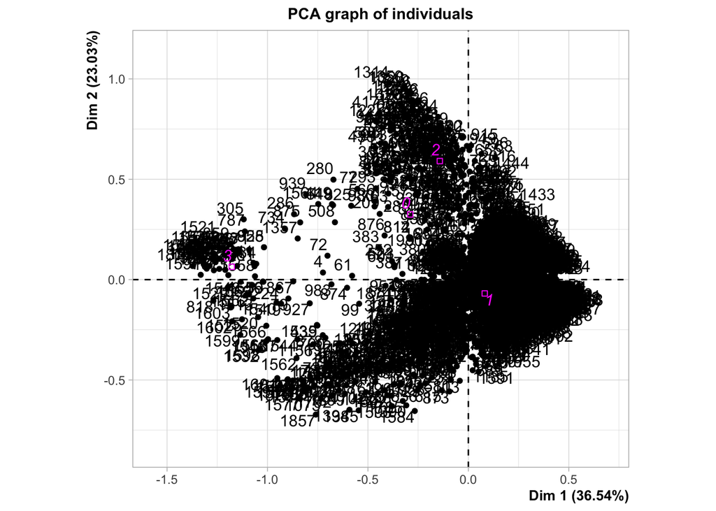

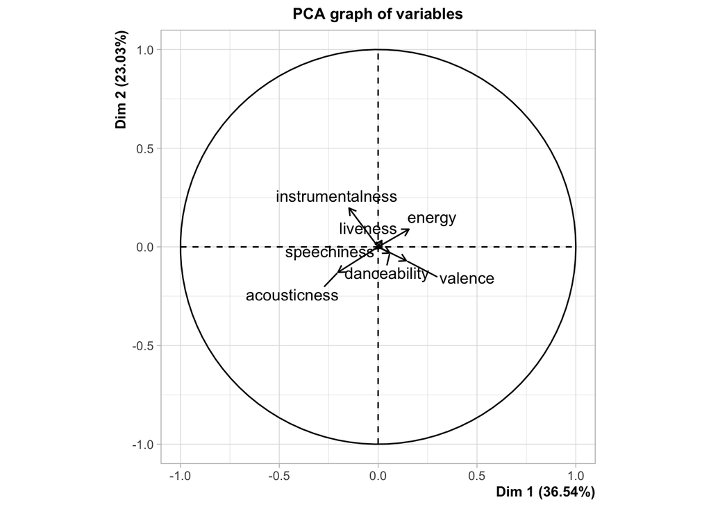

- l’axe 1 oppose les chansons énergiques et joyeuses (à droite du graphique) aux chansons acoustiques et plus instrumentales (à gauche donc) ;
- l’axe 2 oppose les chansons acoustiques (en bas sur le graphique) aux chansons instrumentales (en haut).

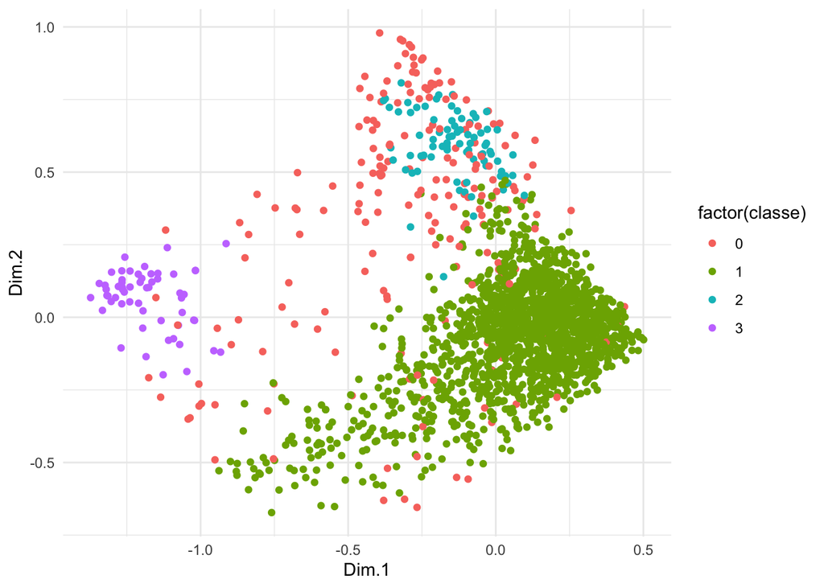

```r
acp_ind = tibble(data.frame(acp$ind$coord)) %>%
         mutate(classe = res$cluster)
ggplot(acp_ind, aes(Dim.1, Dim.2, color = factor(classe))) +
  geom_point() +
  theme_minimal()
```

C’est ce dernier phénomène qui tend à regrouper tous les individus dans une même classe avec DBSCAN.